# Transcriptional profiling of lncRHOXF2B: a novel X-linked long noncoding RNA that regulates early human development

Camille Syrett

August 1, 2015

## Abstract

Early human development requires precise regulation of gene expression in order to facilitate normal embryonic growth. Long noncoding RNAs (lncRNAs) are RNA transcripts lacking coding potential that regulate gene expression during development. We have identified a novel human-specific X-linked lncRNA called lncRHOXF2B, located in the RHOX cluster of the X chromosome. LncRHOXF2B is expressed from a 4.8kb gene to produce a 780 bp transcript, found in both the cytoplasm and the nucleus, and is subject to X-chromosome inactivation. To analyze the function of this novel lncRNA we targeted an inducible lncRHOXF2B transgene to chromosome 9 in human embryonic stem cells (hESCs).Overexpession of lncRHOXF2B in undifferentiated hESCs reduced cellular growth rates and increased differentiation. In this experiment, we examined the transcriptional profile of undifferentiated hESCs overexpressing lncRHOXF2B by illumina microarray. The expression profiling anaylsis along with highlighted results are reviewed below.

## R packages

**The following R/bioconductor packages are used in this analysis:**

```r
library(lumi)
library(lumiHumanIDMapping)
library(lumiHumanAll.db)
library(RColorBrewer)
library(gplots)
library(ggplot2)
library(genefilter)
library(limma)
library(annotate)
library(reshape2)
library(Biobase)
library(dplyr)
```

**This lncRHOXF2B microarray analysis summary report was compiled in Rmarkdown using the following packages:**

```r
library(rmarkdown)
library(knitr)
```

## Set-up & QC

**First, I will read in the raw illumina microarray data and will add in controls**  
**I will remove clone23 and just focus on clone28, and will get rid of the outlier replicate 2**

```r
rawData <- lumiR("FinalReport_noNorm_noBkrnd_samples.txt", convertNuID = TRUE, sep = NULL, detectionTh = 0.01, na.rm = TRUE, lib = "lumiHumanIDMapping")
rawData <- addControlData2lumi("FinalReport_noNorm_noBkrnd_controls.txt", rawData)
rawData <- rawData[,-1:-5] #gets rid of clone23 data
rawData <- rawData[,-2] #gets rid of an outlier replicate for clone28
```

**Next, I will read in a text file that describes the design of this study, and will use this file to set up sample labels, treatment groups for comparison, and replicates**

```r
targets <- read.delim("Anguera_studyDesign_exper2.txt", sep="\t", stringsAsFactors = FALSE)
myGroups <- factor(paste(targets$Ident, targets$Treat, sep="."))
```

### Figure 1: Housekeeping genes

**I begin by analyzing the array quality and consistency by looking at how a set of housekeeping genes behaves on the array**  
*Result: embryonic stem cells appear to have variable housekeeping gene signatures*

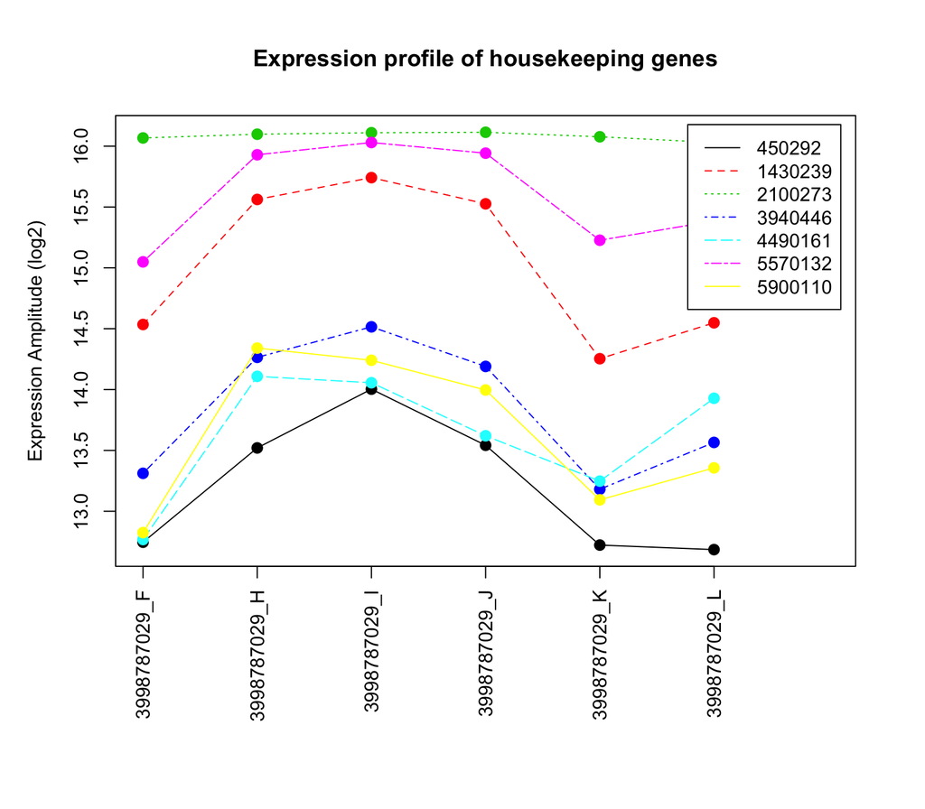

```r
plotHousekeepingGene(rawData)
```

### Figure 2: Distribution of signal intensity

**This is another QC check before normalization or data filtering occurs**

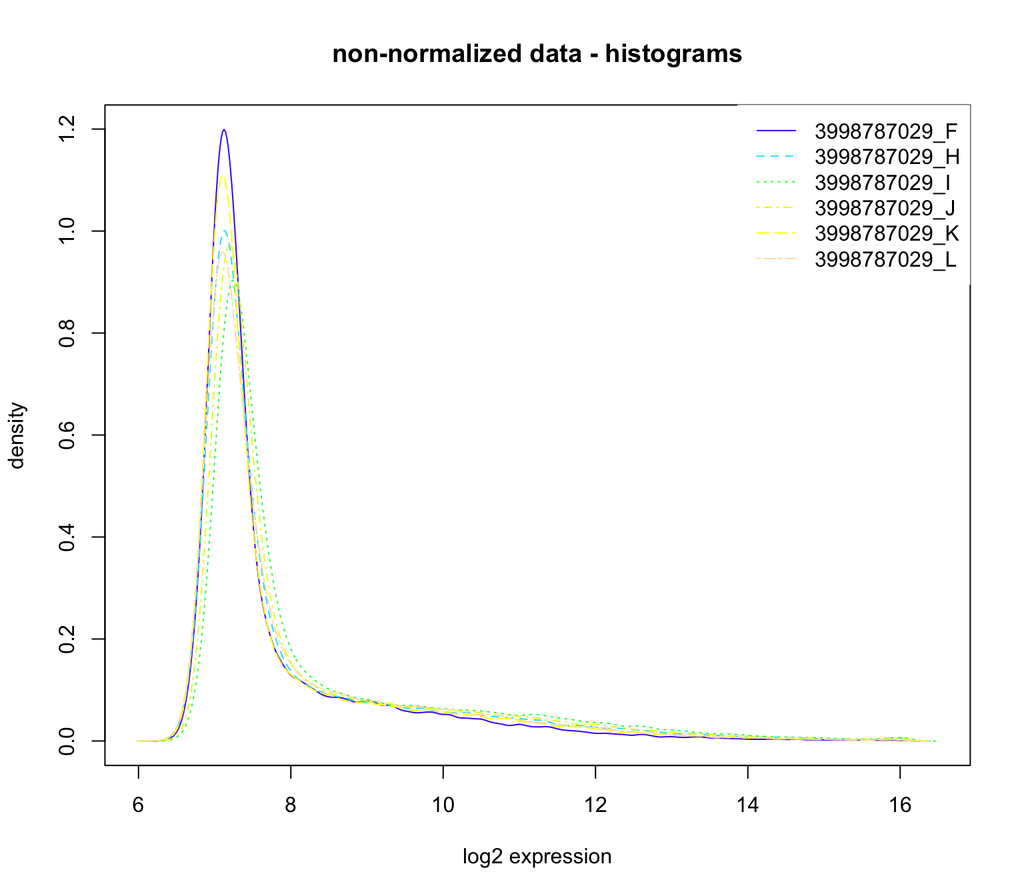

```r
cols <- topo.colors(n=6, alpha=1)
hist(rawData, xlab = "log2 expression", main = "non-normalized data - histograms", col=cols)
```

### Figure 3: Data normalization histogram

**I will continue with the data preprocessing by using Lumi to perform robust spline normalization. This will control for the variation between arrays, and I will repeat the graph in Figure 2 with this normalization**

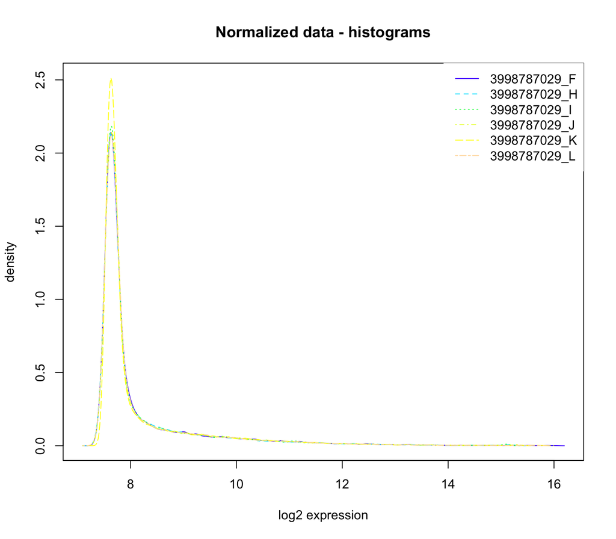

```r
normData <- lumiExpresso(rawData, QC.evaluation=TRUE, normalize.param=list(method='rsn'))
normData@annotation <- "lumiHumanAll.db"
hist(normData, xlab = "log2 expression", main = "Normalized data - histograms", col=cols)
```

### Figure 4: Data normalization boxplot

**I can also view the normalized data in boxplot form**

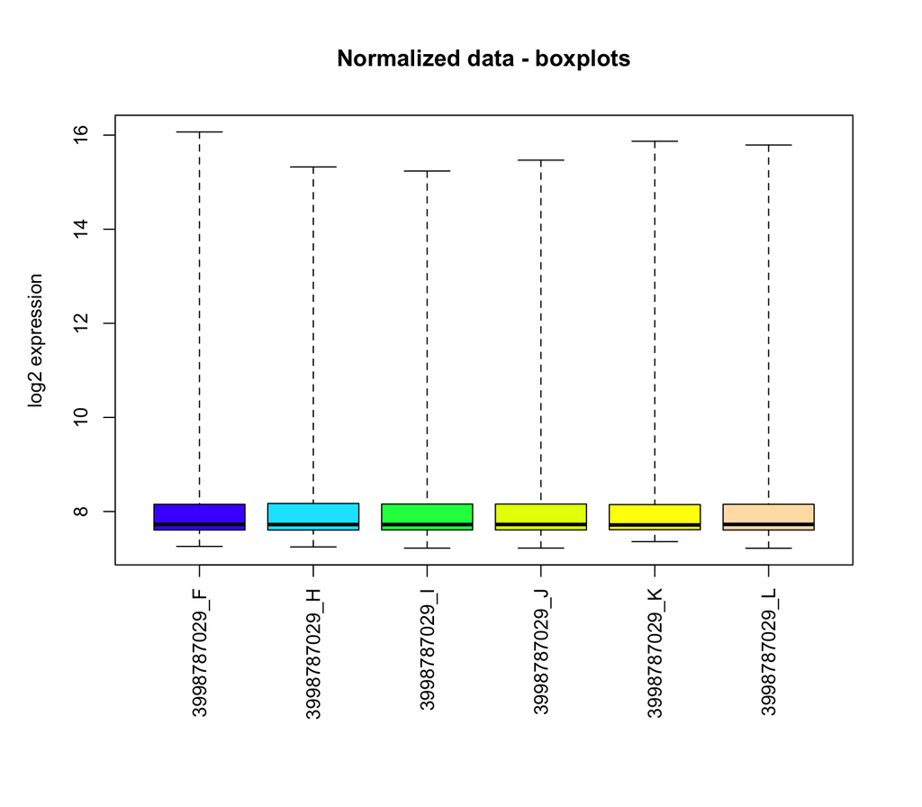

```r
boxplot(normData, ylab = "log2 expression", main = "Normalized data - boxplots", col=cols.ALL)
```

**Finally, I will filter the data to remove genes with (1) a detection rate below the background, (2) a low variation across the 6 samples, (3) duplicates, and (4) those without an EntrezID**

```r
filtered_geneList <- nsFilter(normData, require.entrez=TRUE, remove.dupEntrez=TRUE, var.func=IQR, var.filter=TRUE, var.cutoff=0.5, filterByQuantile=TRUE)
filtered.eset <- filtered_geneList$eset # extract the ExpressionSet from this filtered list
# convert to a datamatrix that will contain only the probes after filtering
filtered.matrix <- as.matrix(filtered.eset)
probeList <- rownames(filtered.matrix)
```

## Exploratory analysis

### Figure 5: Hierarchical clustering

```r
sampleLabels <- paste(targets$Ident, targets$Treat, targets$Rep, sep=".")
distance <- dist(t(filtered.matrix),method="maximum")
clusters <- hclust(distance, method = "complete")
plot(clusters, label = sampleLabels, hang = -1, main="LncRHOXF2B analysis")
```

[figure not shown]

### Figure 6: Principal component analysis I

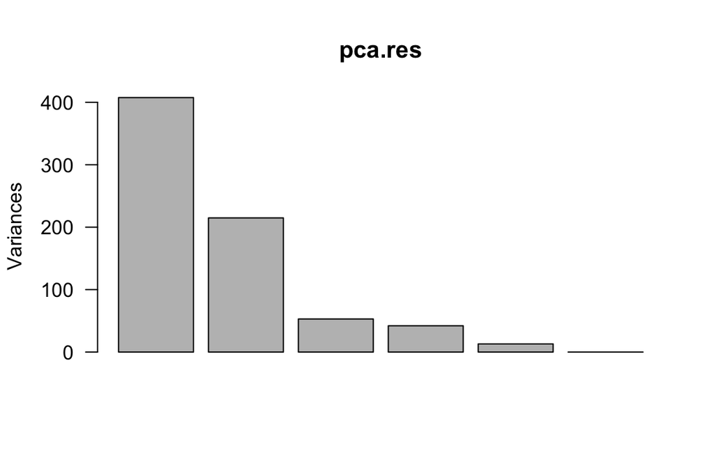

```r
pca.res <- prcomp(t(filtered.matrix), scale.=F, retx=T) #makes R object
ls(pca.res) #lists components of PCA
summary(pca.res) #prints variance summary for all principal components.
head(pca.res$rotation) #rotation shows you how much each GENE influenced each PC
head(pca.res$x) #$x shows you how much each SAMPLE influenced each PC (called 'scores')
plot(pca.res, las=1) #las gives you fine control of the data: turns the vertices
```

```r
pc.var<-pca.res$sdev^2 #sdev^2 gives you the eigenvalues
pc.per<-round(pc.var/sum(pc.var)*100, 1)
pc.per #makes new object (numerical vector) to show percentage of contribution for each PCA
```

### Figure 7: Principal component analysis II

**I will next make a graph to visualize the PCA result by plotting PC1 and PC2 against each other**

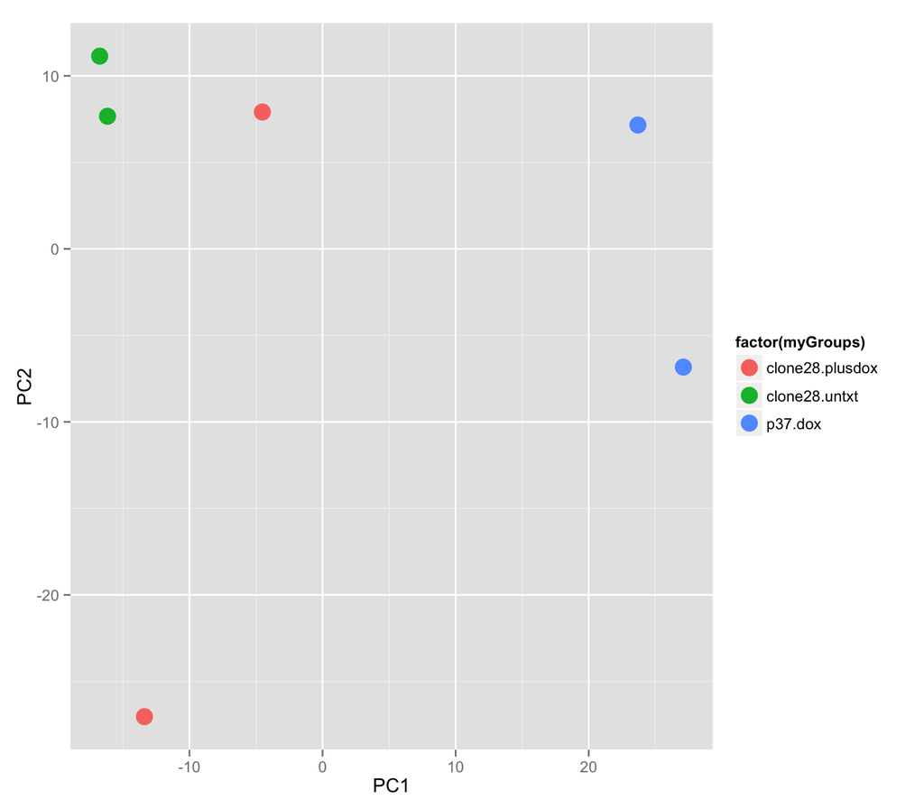

```r
data.frame <- as.data.frame(pca.res$x)
ggplot(data.frame, aes(x=PC1, y=PC2, colour=factor(myGroups))) +
  geom_point(size=5) +
  theme(legend.position="right")
```

### Figure 8: PCA small multiples chart

**Next, I will create a ‘small multiples’ chart to look at impact of each variable on each pricipal component**

```r
melted <- cbind(myGroups, melt(pca.res$x[,1:4])) #look at your 'melted' data
ggplot(melted) +
  geom_bar(aes(x=Var1, y=value, fill=myGroups), stat="identity") +
  facet_wrap(~Var2)
```

[figure not shown]

## Identification of Differentially Expressed Genes

**First, I will set up the experimental design. At this stage I will construct a contrast matrix so that I can begin to compare treatment groups (plus dox and untreated) to determine the list of differentially expressed genes. I will make groups so that all of the clone 28 plus dox are the same, and clone 28 minus dox are the same group, etc.**

```r
design <- model.matrix(~0+myGroups)
colnames(design) <- levels(myGroups) #makes column names exactly what I want
design
```

**To create the DEG list, I will first read in the normalized filtered data, change the table headings to reflect their content, and will use the dply package to calculate averages and fold changes for the treatment groups (plus dox, untreated, and huES9 WT)**

```r
#read in your data from a text file that contains genes symbols as rows, and samples as columns.
myData <- read.delim("normalizedFilteredData.txt", header=TRUE)
#subsetting operations to remove/add columns: we will make ours smaller: [rows,columns] -2 gets rid of column 2
myData <- myData[,-2]
row.names(myData) <- myData[,1]
myData <- myData[,-1]
head(myData)
```

```
##         X3998787029_F X3998787029_H X3998787029_I X3998787029_J
## ADA          9.578877     10.196835      9.811445      9.668738
## CDH2        12.727465     12.466396     13.151107     12.966272
## AKT3         7.688918      7.784887      7.912100      7.988348
## RNA18S5      9.424180      8.520160      8.572957      8.825126
## RNA28S5     10.080981      8.646188      8.971384      9.186701
## MED6        10.936741     10.930679     11.010000     10.989799
##         X3998787029_K X3998787029_L
## ADA          9.175357      9.260412
## CDH2        12.185256     12.364068
## AKT3         7.628926      7.682692
## RNA18S5      8.922661      9.011450
## RNA28S5      9.316808     10.720771
## MED6        11.356416     11.122473
```

**Next, I will change the table headings on the columns to more accurately reflect their content**

```r
targets <- read.delim("Anguera_studyDesign_exper2.txt", sep="\t", stringsAsFactors = FALSE)
sampleLabels <- as.character(paste(targets$Ident, targets$Treat, targets$Rep, sep="."))
colnames(myData) <- sampleLabels
geneSymbols <- row.names(myData)
head(myData)
```

```
##         clone28.plusdox.1 clone28.plusdox.3 clone28.untxt.1
## ADA              9.578877         10.196835        9.811445
## CDH2            12.727465         12.466396       13.151107
## AKT3             7.688918          7.784887        7.912100
## RNA18S5          9.424180          8.520160        8.572957
## RNA28S5         10.080981          8.646188        8.971384
## MED6            10.936741         10.930679       11.010000
##         clone28.untxt.2 p37.dox.day5a p37.dox.day5b
## ADA            9.668738      9.175357      9.260412
## CDH2          12.966272     12.185256     12.364068
## AKT3           7.988348      7.628926      7.682692
## RNA18S5        8.825126      8.922661      9.011450
## RNA28S5        9.186701      9.316808     10.720771
## MED6          10.989799     11.356416     11.122473
```

**Finally, I will use the dplyr ‘mutate’ command to get averages and fold changes for my two replicates in each of the three treatment groups**

```r
myData <- mutate(myData,
                 clone28.plusdox.AVG = (clone28.plusdox.1  + clone28.plusdox.3)/2,
                 clone28.untxt.AVG = (clone28.untxt.1 + clone28.untxt.2)/2,
                 p37.dox.AVG = (p37.dox.day5a + p37.dox.day5b)/2,
                 LogFC.clone28 = (clone28.plusdox.AVG - clone28.untxt.AVG),
                 geneSymbols = geneSymbols)
row.names(myData) <- geneSymbols
head(myData)
```

```
##         clone28.plusdox.1 clone28.plusdox.3 clone28.untxt.1
## ADA              9.578877         10.196835        9.811445
## CDH2            12.727465         12.466396       13.151107
## AKT3             7.688918          7.784887        7.912100
## RNA18S5          9.424180          8.520160        8.572957
## RNA28S5         10.080981          8.646188        8.971384
## MED6            10.936741         10.930679       11.010000
##         clone28.untxt.2 p37.dox.day5a p37.dox.day5b clone28.plusdox.AVG
## ADA            9.668738      9.175357      9.260412            9.887856
## CDH2          12.966272     12.185256     12.364068           12.596931
## AKT3           7.988348      7.628926      7.682692            7.736903
## RNA18S5        8.825126      8.922661      9.011450            8.972170
## RNA28S5        9.186701      9.316808     10.720771            9.363584
## MED6          10.989799     11.356416     11.122473           10.933710
##         clone28.untxt.AVG p37.dox.AVG LogFC.clone28 geneSymbols
## ADA              9.740091    9.217884    0.14776492         ADA
## CDH2            13.058689   12.274662   -0.46175842        CDH2
## AKT3             7.950224    7.655809   -0.21332120        AKT3
## RNA18S5          8.699042    8.967056    0.27312824     RNA18S5
## RNA28S5          9.079042   10.018789    0.28454188     RNA28S5
## MED6            10.999899   11.239444   -0.06618952        MED6
```

**Additionally, using dplyr I can sort by the column of interest (i.e. arrage by LogFC) so that I can display the most differentially expressed genes**

```r
myData.sort <- myData %>%
  arrange(desc(LogFC.clone28)) %>%
  select(geneSymbols, LogFC.clone28)
head(myData.sort)
```

```
##   geneSymbols LogFC.clone28
## 1       CAMKV     0.9702477
## 2      LEFTY1     0.8784327
## 3       SPHK2     0.8116943
## 4         GAL     0.8107635
## 5     SNAR-A1     0.8029395
## 6       CENPV     0.7739661
```

### Figure 9: Basic scatterplot of gene expression

**Using ggplot I will graph these data by creating a basic scatterplot**

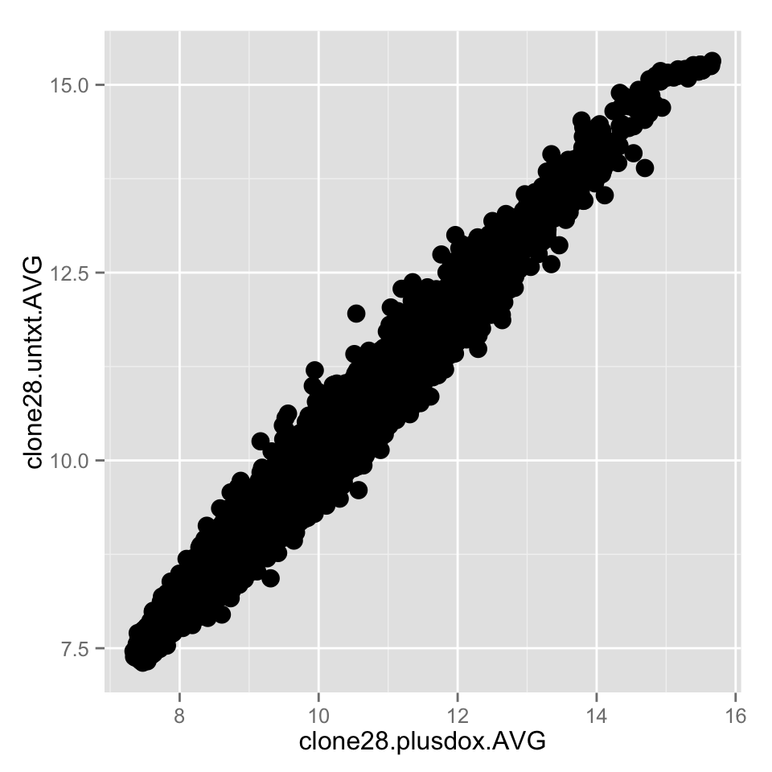

```r
ggplot(myData, aes(x=clone28.plusdox.AVG, y=clone28.untxt.AVG)) +
  geom_point(shape=1) +
  geom_point(size=4)
```

**To generate the DEG list, I will rely purely on fold changes. This is typically done when there are no biological replicates. Although I do have 2 biological replicates, leveraging statistical tools unfortunately did not produce any differentially expressed genes that were significant**  
*Results: this produces a list of 162 differentially expressed genes*

```r
myData.filter <- myData %>%
  filter((abs(LogFC.clone28) >= 0.58)) %>%
  select(geneSymbols, clone28.plusdox.AVG, clone28.untxt.AVG, p37.dox.AVG)
myData.filter
```

```
##     geneSymbols clone28.plusdox.AVG clone28.untxt.AVG p37.dox.AVG
## 1       SNAR-A1           14.695097         13.892157   14.950183
## 2         CDH13            8.390152          9.130336    7.573793
## 3         CEBPZ           11.442156         12.131565   11.680061
## 4        KATNB1            9.800605          9.220116    9.937070
## 5         MCRS1           11.312419         10.615289   11.071367
## 6       ARL6IP5           10.722700         11.460211   10.388641
## 7       ARFGEF1           10.419899         11.005101   10.816669
## 8        IFITM2           13.347513         12.613013   12.986428
## 9         DNPH1           10.039639          9.458199    9.613348
## 10        TXNIP           12.023804         12.822756   10.077300
## 11       LEFTY1            9.308792          8.430360   10.802877
## 12        GNA13            9.729950         10.360537    9.904536
## 13        STAG2           10.729757         11.431305   11.154941
## 14         BTG3           11.236507         11.910575   10.285177
```

[output cut: 148 more lines]

**To generate the heatmap, I need to convert the filtered data object from a dataframe into a matrix**

```r
class(myData.filter) #shows if it is a matrix or data frame
```

```
## [1] "data.frame"
```

```r
myData.filter.matrix <- (myData.filter) #convert data frame to matrix
rownames(myData.filter.matrix) <- myData.filter.matrix[,1]
myData.filter.matrix <- myData.filter.matrix[,-1]
myData.filter.matrix <- as.matrix(myData.filter.matrix)
class(myData.filter.matrix)
```

```
## [1] "matrix"
```

```r
is.matrix(myData.filter.matrix) #tests if argument is a strict matrix
```

```
## [1] TRUE
```

```r
head(myData.filter.matrix)
```

```
##         clone28.plusdox.AVG clone28.untxt.AVG p37.dox.AVG
## SNAR-A1           14.695097         13.892157   14.950183
## CDH13              8.390152          9.130336    7.573793
## CEBPZ             11.442156         12.131565   11.680061
## KATNB1             9.800605          9.220116    9.937070
## MCRS1             11.312419         10.615289   11.071367
## ARL6IP5           10.722700         11.460211   10.388641
```

### Figure 10: Heatmap of differential gene expression

**I will create a tree and color the clusters. I can vary the number of clusters as well as the cut height. Additionally, I will pick a color scheme for the heatmap**

```r
hr <- hclust(as.dist(1-cor(t(myData.filter.matrix), method="pearson")), method="complete") #cluster rows by pearson correlation
hc <- hclust(as.dist(1-cor(myData.filter.matrix, method="spearman")), method="complete") #cluster columns by spearman correlation
mycl <- cutree(hr, k=2)
mycolhc <- rainbow(length(unique(mycl)), start=0.1, end=0.9)
mycolhc <- mycolhc[as.vector(mycl)]
myheatcol <- colorpanel(40, "darkblue", "yellow", "white")
#plot the hclust results as a heatmap
heatmap.2(myData.filter.matrix, Rowv=as.dendrogram(hr), Colv=NA,
          col=myheatcol, scale="row", labRow=NA,
          density.info="none", trace="none", RowSideColors=mycolhc,
          cexRow=1, cexCol=.75, margins=c(10,30), key=T)
```

[figure not shown]